# Met Office API

### Imports

```r
library(httr)
library(jsonlite)
library(tidyverse)
library(lubridate)
```

### Retrieving the site list

In the code below we retrieve the site list and convert the response into a data frame.

Note that my `API_KEY` is hidden - it is available as an environment variable in a special file called `.Renviron`. You can read more about setting up your R environment variables [here](https://daattali.gitbooks.io/stat545-ubc-github-io/content/bit003_api-key-env-var.html). You can replace the `Sys.getnv(...)` code with your API key (as a string), but you should be careful not to upload this to Github!

```r
# Your API key goes here! I am hiding mine :)
API_KEY <- Sys.getenv('MET_API_KEY')

# Getting site list
url <- sprintf('http://datapoint.metoffice.gov.uk/public/data/val/wxfcs/all/json/sitelist?key=%s', API_KEY)

r <- GET(url)
sitelist <- fromJSON(content(r, 'text'))
```

```
## No encoding supplied: defaulting to UTF-8.
```

```r
sitelist <- sitelist$Locations$Location %>% tibble()
```

We’ll now retrieve the Land’s End location ID.

```r
# Land's End
sitelist %>% filter(name == "Land's End")
```

| elevation | id | latitude | longitude | name | region | unitaryAuthArea | obsSource | nationalPark |
| --- | --- | --- | --- | --- | --- | --- | --- | --- |
| 63.0 | 352205 | 50.0641 | -5.709 | Land's End | sw | Cornwall | NA | NA |

### Retrieving the Forecast

```r
location_id <- '352205'

url <- sprintf('http://datapoint.metoffice.gov.uk/public/data/val/wxfcs/all/json/%s?res=3hourly&key=%s', location_id, API_KEY)

r <- GET(url)

data <- fromJSON(content(r, 'text'))
```

```
## No encoding supplied: defaulting to UTF-8.
```

The `Wx` component of the response describes each of the parameters:

```r
data$SiteRep$Wx$Param
```

|  | name | units | $ |
| --- | --- | --- | --- |
| 1 | F | C | Feels Like Temperature |
| 2 | G | mph | Wind Gust |
| 3 | H | % | Screen Relative Humidity |
| 4 | T | C | Temperature |
| 5 | V |  | Visibility |
| 6 | D | compass | Wind Direction |
| 7 | S | mph | Wind Speed |
| 8 | U |  | Max UV Index |
| 9 | W |  | Weather Type |
| 10 | Pp | % | Precipitation Probability |

The following code runs a for loop over the data frames to retrieve the forecast.

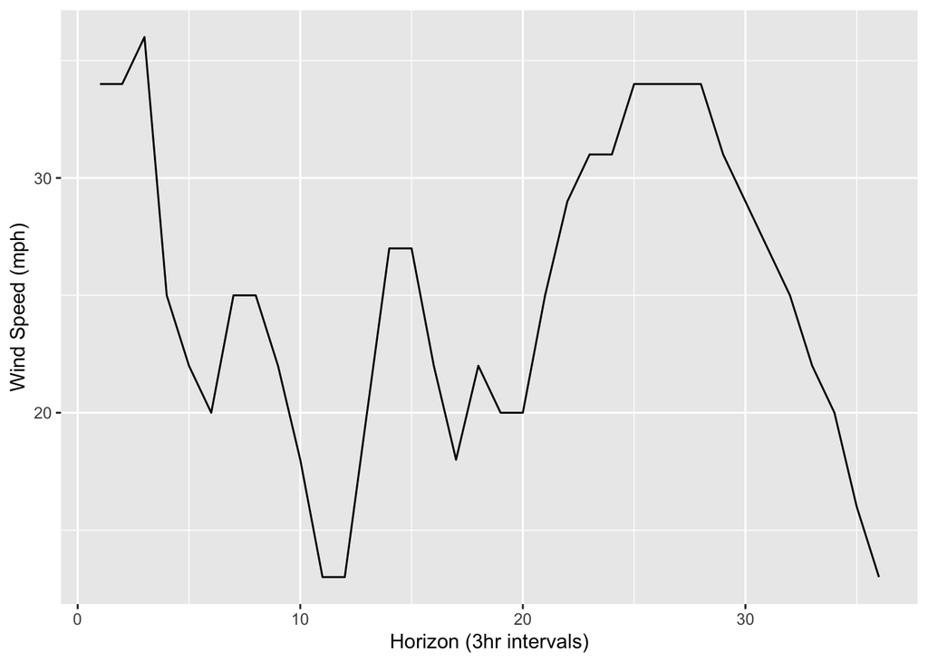

```r
# Create an empty vector to store the results
forecast <- numeric()
for (df in data$SiteRep$DV$Location$Period$Rep){
  forecast <- c(forecast, as.integer(df$S))
}

qplot(1:length(forecast), forecast, geom = 'line') +
  labs(x = "Horizon (3hr intervals)",
       y = "Wind Speed (mph)")
```

### Retrieving the Feels Like Temperature (F) for tomorrow at midday

An additional query parameter can be added to the URL specifiying a time if we just want the forecast for one period. The code below uses this request to get the Feels Like Temperature (F) for tomorrow at midday. **Note: the forecasts are only available at 3 hour intervals, so forecasts only exist for 0, 3, 6,…, 21h. It is not possible to retrieve a forecast for 1am!**

First, we must define the time we want to request for: we will use lubridate period functions (`days()` and `hours()`) for this:

```r
# Specify time to get forecast and convert to ISO 8601 format (lubridate)
time <- (today() + days(1) + hours(12)) %>% # Time tomorrow at midday
  format_ISO8601()
```

Now we will make the request, parse the data and print the results

```r
# Specify location ID
location_id <- '352205'

# Putting together the URL
url <- sprintf('http://datapoint.metoffice.gov.uk/public/data/val/wxfcs/all/json/%s?res=3hourly&time=%s&key=%s', location_id, time, API_KEY)

# Making the request and parsing
r <- GET(url)
data <- fromJSON(content(r, 'text'))
```

```
## No encoding supplied: defaulting to UTF-8.
```

```r
# Retrieve the Feels Like Temperature
feels_like_temp <- data$SiteRep$DV$Location$Period$Rep$F
print(sprintf("The feels like temperature at 12:00 tomorrow will be: %sC", feels_like_temp))
```

```
## [1] "The feels like temperature at 12:00 tomorrow will be: 4C"
```